# Dunyeng Huh Open Ended Data Assessment (2)

```python
import seaborn as sns
from sklearn.preprocessing import OneHotEncoder
from sklearn.preprocessing import LabelEncoder
from sklearn.ensemble import RandomForestRegressor
from sklearn.metrics import mean_absolute_error
import pandas as pd
from sklearn.model_selection import train_test_split
import numpy as np
import matplotlib.pyplot as plt


import os
import geopandas as gpd
import folium
from folium import plugins
import datetime
import math

df = pd.read_csv('/Users/dunyenghuh/Downloads/TRAIN_SET.csv')
# df = pd.read_csv('data/TRAIN_SET.csv')

print("The shape of the data is: ", df.shape)
df.head()
```

```
The shape of the data is:  (15673, 28)
```

|  | RESTAURANT_SERIAL_NUMBER | RESTAURANT_PERMIT_NUMBER | RESTAURANT_NAME | RESTAURANT_LOCATION | RESTAURANT_CATEGORY | ADDRESS | CITY | STATE | ZIP | CURRENT_DEMERITS | ... | RECORD_UPDATED | LAT_LONG_RAW | FIRST_VIOLATION | SECOND_VIOLATION | THIRD_VIOLATION | FIRST_VIOLATION_TYPE | SECOND_VIOLATION_TYPE | THIRD_VIOLATION_TYPE | NUMBER_OF_VIOLATIONS | NEXT_INSPECTION_GRADE_C_OR_BELOW |
| --- | --- | --- | --- | --- | --- | --- | --- | --- | --- | --- | --- | --- | --- | --- | --- | --- | --- | --- | --- | --- | --- |
| 0 | DA1117270 | PR0004527 | SANDS EXPO HALL B2 CONCESSION | SANDS EXPO & CONVENTION CENTER | Snack Bar | 201 E Sands Ave | Las Vegas | Nevada | 89169-2617 | 0.0 | ... | 1/6/2015 16:34 | (36.1221442, 115.1652749) | 204.0 | 215.0 | 302.0 | Critical | Major | Imminent Health Hazard | 4.0 | 0.0 |
| 1 | DA1014948 | PR0024221 | THAI NOODLES CAFE - RESTAURANT | THAI NOODLES CAFE | Restaurant | 6710 W CHEYENNE Ave | Las Vegas | Nevada | 89108-4588 | 3.0 | ... | 2/21/2013 22:26 | (36.218691, 115.242913) | 214.0 | 216.0 | 229.0 | Major | Major | Non-Major | 5.0 | 0.0 |
| 2 | DA0861994 | PR0019017 | SANTA FE SPORTS BOOK GRILL | Santa Fe Station Hotel & Casino | Restaurant | 4949 N Rancho Dr | Las Vegas | Nevada | 89130-3505 | 8.0 | ... | 4/6/2015 9:00 | (36.2498922, 115.2441383) | 202.0 | 215.0 | 233.0 | Critical | Major | Non-Major | 3.0 | 1.0 |
| 3 | DA0896719 | PR0001343 | Bracken, Walter Elem School Kit | Bracken, Walter Elem School | Elementary School Kitchen | 1200 N 27Th St | Las Vegas | Nevada | 89101-1517 | 0.0 | ... | 2/21/2013 22:26 | (36.183669, 115.112355) | 214.0 | 230.0 | 233.0 | Major | Non-Major | Non-Major | 3.0 | 0.0 |
| 4 | DA1031041 | PR0006084 | HARD ROCK JOINT EAST SVC BAR FL 1 | HARD ROCK HOTEL & CASINO | Bar / Tavern | 4455 S Paradise Rd | Las Vegas | Nevada | 89169-6574 | 0.0 | ... | 2/21/2013 22:26 | (36.1100828, 115.1538714) | 214.0 | 230.0 | 233.0 | Major | Non-Major | Non-Major | NaN | 0.0 |

5 rows × 28 columns

```python
null_columns = [col for col in df.columns if df[col].isnull().any() == True]
print("we have less than 2%(appx 300) of missing entry for all the columns ")
pd.DataFrame(df[null_columns].isnull().sum() / len(df), columns={'Percentage of Null Value'})
```

```
we have less than 2%(appx 300) of missing entry for all the columns
```

|  | Percentage of Null Value |
| --- | --- |
| RESTAURANT_NAME | 0.004147 |
| RESTAURANT_LOCATION | 0.012761 |
| RESTAURANT_CATEGORY | 0.008295 |
| ADDRESS | 0.004466 |
| CITY | 0.015058 |
| STATE | 0.013335 |
| ZIP | 0.003764 |
| CURRENT_DEMERITS | 0.013782 |
| CURRENT_GRADE | 0.019652 |
| EMPLOYEE_COUNT | 0.005934 |
| MEDIAN_EMPLOYEE_AGE | 0.002169 |
| MEDIAN_EMPLOYEE_TENURE | 0.018950 |
| INSPECTION_TIME | 0.011676 |
| INSPECTION_TYPE | 0.014164 |
| INSPECTION_DEMERITS | 0.016206 |
| VIOLATIONS_RAW | 0.010528 |
| RECORD_UPDATED | 0.007593 |
| LAT_LONG_RAW | 0.000893 |
| FIRST_VIOLATION | 0.013526 |
| SECOND_VIOLATION | 0.005423 |
| THIRD_VIOLATION | 0.003892 |
| FIRST_VIOLATION_TYPE | 0.009315 |
| SECOND_VIOLATION_TYPE | 0.017036 |
| THIRD_VIOLATION_TYPE | 0.011038 |
| NUMBER_OF_VIOLATIONS | 0.010783 |
| NEXT_INSPECTION_GRADE_C_OR_BELOW | 0.002552 |

```
Text(0.5,1,'counts of missing value')
```

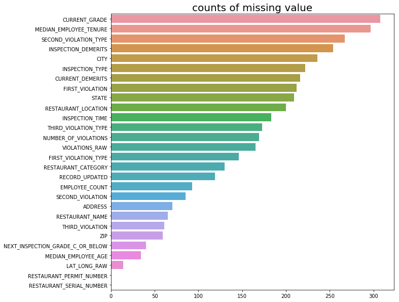

```python
plt.figure(figsize=(10,10))
sns.barplot(x=df.isnull().sum().sort_values(ascending=False),y=df.isnull().sum().sort_values(ascending=False).index)
plt.title("counts of missing value",size=20)
```

```python
categorical = [col for col in df.columns if df[col].dtypes == object]
numerical = [col for col in df.columns if df[col].dtypes != object]
feature_selection = []
print(categorical)
print(numerical)
```

```
['RESTAURANT_SERIAL_NUMBER', 'RESTAURANT_PERMIT_NUMBER', 'RESTAURANT_NAME', 'RESTAURANT_LOCATION', 'RESTAURANT_CATEGORY', 'ADDRESS', 'CITY', 'STATE', 'ZIP', 'CURRENT_GRADE', 'INSPECTION_TIME', 'INSPECTION_TYPE', 'VIOLATIONS_RAW', 'RECORD_UPDATED', 'LAT_LONG_RAW', 'FIRST_VIOLATION_TYPE', 'SECOND_VIOL…
['CURRENT_DEMERITS', 'EMPLOYEE_COUNT', 'MEDIAN_EMPLOYEE_AGE', 'MEDIAN_EMPLOYEE_TENURE', 'INSPECTION_DEMERITS', 'FIRST_VIOLATION', 'SECOND_VIOLATION', 'THIRD_VIOLATION', 'NUMBER_OF_VIOLATIONS', 'NEXT_INSPECTION_GRADE_C_OR_BELOW']
```

```python
df.corr().NEXT_INSPECTION_GRADE_C_OR_BELOW.sort_values()
```

```
MEDIAN_EMPLOYEE_AGE                -0.004694
MEDIAN_EMPLOYEE_TENURE             -0.002004
EMPLOYEE_COUNT                      0.001501
THIRD_VIOLATION                     0.013105
FIRST_VIOLATION                     0.015604
SECOND_VIOLATION                    0.015944
CURRENT_DEMERITS                    0.036236
INSPECTION_DEMERITS                 0.076680
NUMBER_OF_VIOLATIONS                0.077507
NEXT_INSPECTION_GRADE_C_OR_BELOW    1.000000
Name: NEXT_INSPECTION_GRADE_C_OR_BELOW, dtype: float64
```

## EDA

### Target Variable

```python
print("number of nulls in target variable: ",df.NEXT_INSPECTION_GRADE_C_OR_BELOW.isnull().sum())
print("percentage of the value 1 is :",df.NEXT_INSPECTION_GRADE_C_OR_BELOW.sum() / (len(df)-40))
df.NEXT_INSPECTION_GRADE_C_OR_BELOW.value_counts()
```

```
number of nulls in target variable:  40
percentage of the value 1 is : 0.1581270389560545
```

```
0.0    13161
1.0     2472
Name: NEXT_INSPECTION_GRADE_C_OR_BELOW, dtype: int64
```

#### There exists a huge class imbalance within the test dataset

#### Thus, my model / prediction should have at least 84.1% accuracy

### Restaurant Information

```python
import collections

print(df.RESTAURANT_SERIAL_NUMBER.nunique())
print("Serial Number is a unique identifier")
```

```
15673
Serial Number is a unique identifier
```

```python
print(df.RESTAURANT_PERMIT_NUMBER.nunique())
collections.Counter(df.RESTAURANT_PERMIT_NUMBER)
print("some restaurants share permit number")
print(df.RESTAURANT_NAME.nunique())
collections.Counter(df.RESTAURANT_NAME)
print('some restaurants share name')
```

```
8654
some restaurants share permit number
8322
some restaurants share name
```

```
Restaurant                     9319
Bar / Tavern                   2379
Snack Bar                      1285
Special Kitchen                1160
Buffet                          228
Portable Unit                   199
Pantry                          166
Meat/Poultry/Seafood            140
Food Trucks / Mobile Vendor      99
Caterer                          71
Banquet Kitchen                  65
Kitchen Bakery                   61
Bakery Sales                     47
Garde Manger                     47
Vegetable Prep                   44
Produce Market                   33
Institutional Food Service       32
Concessions                      29
Confection                       26
Elementary School Kitchen        20
Grocery Store Sampling           19
Banquet Support                  16
Childcare Kitchens               15
Portable Bar                     15
Barbeque                         14
Main Kitchen                      8
Beer Bar                          3
Farmers Market                    2
Self-Service Food Truck           1
Name: RESTAURANT_CATEGORY, dtype: int64
```

```
Text(0.5,1,'Proportion of restaurant categories with NEXT INSPECTION C or BELOW as 1')
```

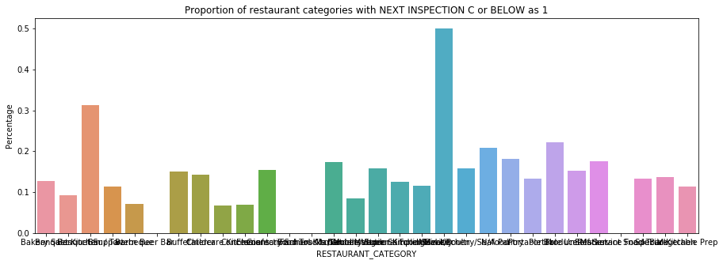

```python
print(df.RESTAURANT_CATEGORY.value_counts())

restaurant_category = pd.DataFrame(df.groupby(df.RESTAURANT_CATEGORY.fillna("N/A")).NEXT_INSPECTION_GRADE_C_OR_BELOW.sum()
                    /df.groupby(df.RESTAURANT_CATEGORY.fillna("N/A")).NEXT_INSPECTION_GRADE_C_OR_BELOW.count()).reset_index()

sns.barplot(restaurant_category.RESTAURANT_CATEGORY,restaurant_category.NEXT_INSPECTION_GRADE_C_OR_BELOW)
plt.ylabel("Percentage")
plt.title("Proportion of restaurant categories with NEXT INSPECTION C or BELOW as 1")
```

```python
print("Inspection grade may varies by restaurange category. Need to one-hot encode this column")
feature_selection.append('RESTAURANT_CATEGORY')
restaurant_category.sort_values(by = ['NEXT_INSPECTION_GRADE_C_OR_BELOW'], ascending=False)[:5]
```

```
Inspection grade may varies by restaurange category. Need to one-hot encode this column
```

|  | RESTAURANT_CATEGORY | NEXT_INSPECTION_GRADE_C_OR_BELOW |
| --- | --- | --- |
| 18 | Main Kitchen | 0.500000 |
| 2 | Banquet Support | 0.312500 |
| 23 | Portable Unit | 0.221106 |
| 20 | N/A | 0.209302 |
| 21 | Pantry | 0.180723 |

### Restaurant Address / Location

```python
print("Unique Restaurant Location: " ,df.RESTAURANT_LOCATION.nunique())
print("Unique Restaurant Address: ",df.ADDRESS.nunique())
```

```
Unique Restaurant Location:  4963
Unique Restaurant Address:  4784
```

```
Unique Cityies restaurant is located in:  19
Degree of inspection might differ from city to city. Might need to one-hot encode this column
```

```
Text(0.5,1,'Proportion of restaurants with NEXT INSPECTION C or BELOW')
```

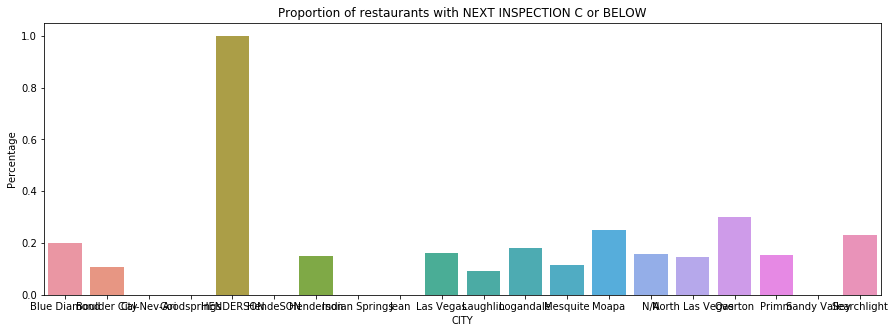

```python
print("Unique Cityies restaurant is located in: ",df.CITY.nunique())
print("Degree of inspection might differ from city to city. Might need to one-hot encode this column ")
df.CITY.value_counts()
feature_selection.append('CITY')

city = pd.DataFrame(df.groupby(df.CITY.fillna("N/A")).NEXT_INSPECTION_GRADE_C_OR_BELOW.sum()
                    /df.groupby(df.CITY.fillna("N/A")).NEXT_INSPECTION_GRADE_C_OR_BELOW.count()).reset_index()

sns.barplot(city.CITY,city.NEXT_INSPECTION_GRADE_C_OR_BELOW)
plt.ylabel("Percentage")
plt.title("Proportion of restaurants with NEXT INSPECTION C or BELOW")
```

```python
print("Inspection grade varies by city. Need to one-hot encode this column")
city.sort_values(by = ['NEXT_INSPECTION_GRADE_C_OR_BELOW'], ascending=False)[:10]
```

```
Inspection grade varies by city. Need to one-hot encode this column
```

|  | CITY | NEXT_INSPECTION_GRADE_C_OR_BELOW |
| --- | --- | --- |
| 4 | HENDERSON | 1.000000 |
| 16 | Overton | 0.300000 |
| 13 | Moapa | 0.250000 |
| 19 | Searchlight | 0.230769 |
| 0 | Blue Diamond | 0.200000 |
| 11 | Logandale | 0.181818 |
| 9 | Las Vegas | 0.162372 |
| 14 | N/A | 0.157447 |
| 17 | Primm | 0.155340 |
| 6 | Henderson | 0.149007 |

```
Unique STATES restaurant is located in:  1
The data comes from city of Las Vegas data portal. We can probably ignore this column
Unique restaurant ZIPCODE:  2480
The data has zipcode in 2 different formats. I will just use the first five numbers for grouping purpose
Unique restaurant ZIPCODE (first 5 #):  93
city and zipcode gives me similar results. Because there are too many unique zipcodes I will use city as predictor variable
```

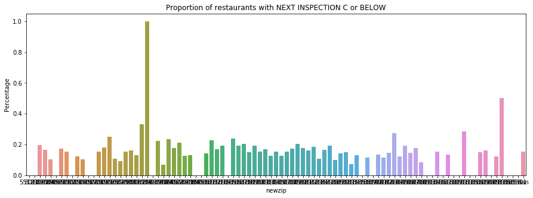

```python
print("Unique STATES restaurant is located in: ",df.STATE.nunique())
print("The data comes from city of Las Vegas data portal. We can probably ignore this column ")
print("Unique restaurant ZIPCODE: ",df.ZIP.nunique())
print("The data has zipcode in 2 different formats. I will just use the first five numbers for grouping purpose")
df['newzip'] = df.ZIP.apply(lambda x: str(x)[:5] )
print("Unique restaurant ZIPCODE (first 5 #): ",df.newzip.nunique())


newzip = pd.DataFrame(df.groupby(df.newzip.fillna("N/A")).NEXT_INSPECTION_GRADE_C_OR_BELOW.sum()
                    /df.groupby(df.newzip.fillna("N/A")).NEXT_INSPECTION_GRADE_C_OR_BELOW.count()).reset_index()

sns.barplot(newzip.newzip,newzip.NEXT_INSPECTION_GRADE_C_OR_BELOW)
plt.ylabel("Percentage")
plt.title("Proportion of restaurants with NEXT INSPECTION C or BELOW")

print("city and zipcode gives me similar results. Because there are too many unique zipcodes I will use city as predictor variable ")
```

### Grades / Demerits

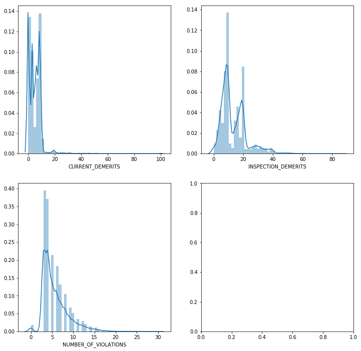

```python
fig,ax=plt.subplots(2,2,figsize=(12,12))
#Inspection demerit scores range from 0 to 100 points. A "0" demerit score indicates that no violations were identified during the inspection. Food establishments strive to receive a "0" demerit score on their inspection to show exemplary compliance with the regulations.
#print("The distribution is heavily skewed to the right")

sns.distplot(df.CURRENT_DEMERITS.fillna(0), ax=ax[0,0])
sns.distplot(df.INSPECTION_DEMERITS.fillna(0), ax=ax[0,1])
sns.distplot(df.NUMBER_OF_VIOLATIONS.fillna(0), ax=ax[1,0])
#df.CURRENT_DEMERITS.describe()
```

```python
print ("count of null values for current demerits: " , df.CURRENT_DEMERITS.isnull().sum())
```

```
count of null values for current demerits:  216
```

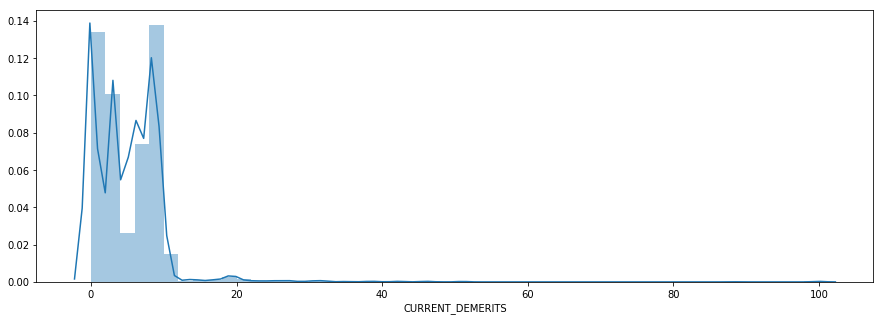

```python
sns.distplot(df.CURRENT_DEMERITS.fillna(0))
```

```python
print(df.CURRENT_GRADE.value_counts())
```

```
A    14927
B      214
C      104
X       75
O       32
N       13
Name: CURRENT_GRADE, dtype: int64
```

```
Text(0.5,1,'Proportion of restaurants with NEXT INSPECTION C or BELOW')
```

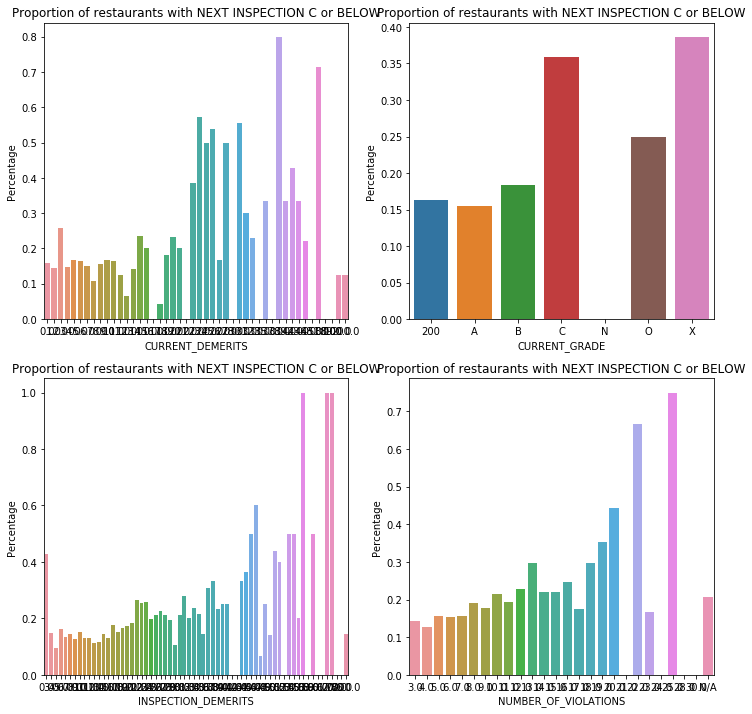

```python
fig,ax=plt.subplots(2,2,figsize=(12,12))

# fill nan values with 200, to differentiate from restaurants with 0 demerits
current_demerits = pd.DataFrame(df.groupby(df.CURRENT_DEMERITS.fillna(200)).NEXT_INSPECTION_GRADE_C_OR_BELOW.sum()/df.groupby(df.CURRENT_DEMERITS.fillna(200)).NEXT_INSPECTION_GRADE_C_OR_BELOW.count()).reset_index()
sns.barplot(current_demerits.CURRENT_DEMERITS,current_demerits.NEXT_INSPECTION_GRADE_C_OR_BELOW, ax=ax[0,0])
ax[0,0].set_ylabel("Percentage")
ax[0,0].set_title("Proportion of restaurants with NEXT INSPECTION C or BELOW")

temp = pd.DataFrame(df.groupby(df.CURRENT_GRADE.fillna(200)).NEXT_INSPECTION_GRADE_C_OR_BELOW.sum()
                    /df.groupby(df.CURRENT_GRADE.fillna(200)).NEXT_INSPECTION_GRADE_C_OR_BELOW.count()).reset_index()
sns.barplot(temp.CURRENT_GRADE,temp.NEXT_INSPECTION_GRADE_C_OR_BELOW, ax=ax[0,1])
ax[0,1].set_ylabel("Percentage")
ax[0,1].set_title("Proportion of restaurants with NEXT INSPECTION C or BELOW")

inspection_demerits = pd.DataFrame(df.groupby(df.INSPECTION_DEMERITS.fillna(200)).NEXT_INSPECTION_GRADE_C_OR_BELOW.sum()
                    /df.groupby(df.INSPECTION_DEMERITS.fillna(200)).NEXT_INSPECTION_GRADE_C_OR_BELOW.count()).reset_index()
sns.barplot(inspection_demerits.INSPECTION_DEMERITS,inspection_demerits.NEXT_INSPECTION_GRADE_C_OR_BELOW, ax=ax[1,0])
ax[1,0].set_ylabel("Percentage")
ax[1,0].set_title("Proportion of restaurants with NEXT INSPECTION C or BELOW")

number_of_violations = pd.DataFrame(df.groupby(df.NUMBER_OF_VIOLATIONS.fillna('N/A')).NEXT_INSPECTION_GRADE_C_OR_BELOW.sum()
                    /df.groupby(df.NUMBER_OF_VIOLATIONS.fillna('N/A')).NEXT_INSPECTION_GRADE_C_OR_BELOW.count()).reset_index()
sns.barplot(number_of_violations.NUMBER_OF_VIOLATIONS,number_of_violations.NEXT_INSPECTION_GRADE_C_OR_BELOW, ax=ax[1,1])
ax[1,1].set_ylabel("Percentage")
ax[1,1].set_title("Proportion of restaurants with NEXT INSPECTION C or BELOW")
```

```python
feature_selection.append('CURRENT_DEMERITS')
print("More Restaurants with high current demerits received C or Below. Add variable to feature ")

feature_selection.append('CURRENT_GRADE')
print("More than 35% of Restaurants who got current grade of (C or X) got C or below from the next inspection")
print("Not sure what N,O,X suggests, but N seems to be Missing Not At Random")

feature_selection.append('INSPECTION_DEMERITS')
print("More restaurants with higher inspection demerits tend to get low inspection grade. Include in modeling")

feature_selection.append('NUMBER_OF_VIOLATIONS')
print("More restaurants with higher number of violations tend to get low inspection grade. Include variable in modeling")
```

[output not shown]

### Employee Info

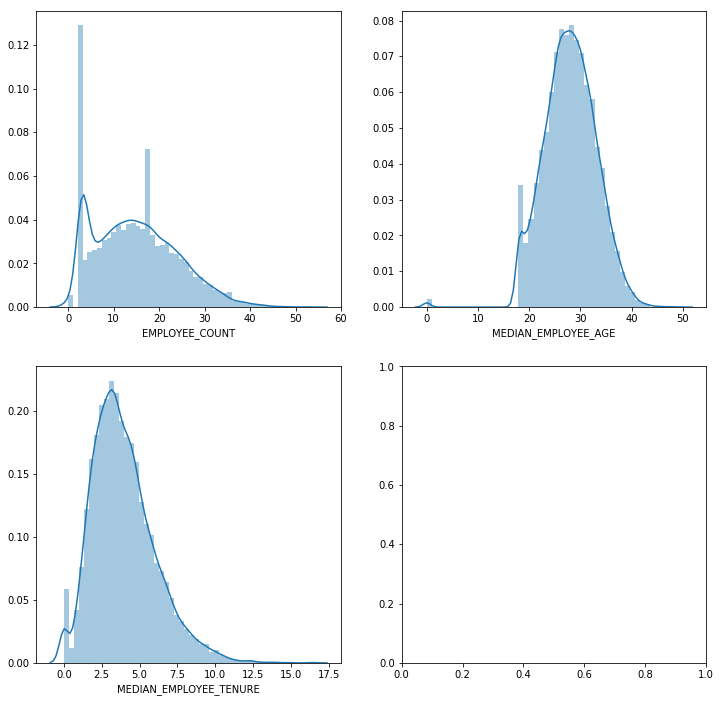

```python
fig,ax=plt.subplots(2,2,figsize=(12,12))
sns.distplot(df.EMPLOYEE_COUNT.fillna(0), ax=ax[0,0])
sns.distplot(df.MEDIAN_EMPLOYEE_AGE.fillna(0), ax=ax[0,1])
sns.distplot(df.MEDIAN_EMPLOYEE_TENURE.fillna(0), ax=ax[1,0])
```

```
Inspection grade does not vary as much by employee count compared to other variables above. (There are only 2 restaurants with employee count 48, and one of them had low grade)
```

```
Text(0.5,1,'Proportion of restaurants with NEXT INSPECTION C or BELOW')
```

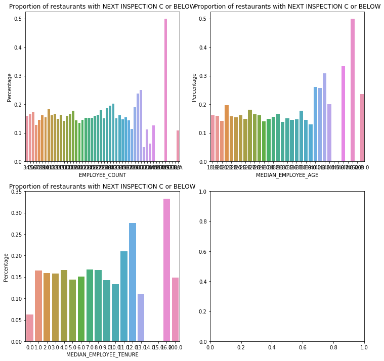

```python
fig,ax=plt.subplots(2,2,figsize=(12,12))

employee_count = pd.DataFrame(df.groupby(df.EMPLOYEE_COUNT.fillna('N/A')).NEXT_INSPECTION_GRADE_C_OR_BELOW.sum()
                    /df.groupby(df.EMPLOYEE_COUNT.fillna('N/A')).NEXT_INSPECTION_GRADE_C_OR_BELOW.count()).reset_index()

sns.barplot(employee_count.EMPLOYEE_COUNT,employee_count.NEXT_INSPECTION_GRADE_C_OR_BELOW, ax= ax[0,0])
ax[0,0].set_ylabel("Percentage")
ax[0,0].set_title("Proportion of restaurants with NEXT INSPECTION C or BELOW")

median_employee_age = pd.DataFrame(df.groupby(df.MEDIAN_EMPLOYEE_AGE.fillna(200).round(0)).NEXT_INSPECTION_GRADE_C_OR_BELOW.sum()
                    /df.groupby(df.MEDIAN_EMPLOYEE_AGE.fillna(200).round(0)).NEXT_INSPECTION_GRADE_C_OR_BELOW.count()).reset_index()

sns.barplot(median_employee_age.MEDIAN_EMPLOYEE_AGE,median_employee_age.NEXT_INSPECTION_GRADE_C_OR_BELOW, ax= ax[0,1])
ax[0,1].set_ylabel("Percentage")
ax[0,1].set_title("Proportion of restaurants with NEXT INSPECTION C or BELOW")


print("Inspection grade does not vary as much by employee count compared to other variables above. (There are only 2 restaurants with employee count 48, and one of them had low grade)")

median_employee_tenure = pd.DataFrame(df.groupby(df.MEDIAN_EMPLOYEE_TENURE.fillna(200).round(0)).NEXT_INSPECTION_GRADE_C_OR_BELOW.sum()
                    /df.groupby(df.MEDIAN_EMPLOYEE_TENURE.fillna(200).round(0)).NEXT_INSPECTION_GRADE_C_OR_BELOW.count()).reset_index()

sns.barplot(median_employee_tenure.MEDIAN_EMPLOYEE_TENURE,median_employee_tenure.NEXT_INSPECTION_GRADE_C_OR_BELOW, ax= ax[1,0])
ax[1,0].set_ylabel("Percentage")
ax[1,0].set_title("Proportion of restaurants with NEXT INSPECTION C or BELOW")
```

```python
print("Unsure if Employee-related variables are meaningful")
```

```
Unsure if Employee-related variables are meaningful
```

### Inspections / Time

```python
df.INSPECTION_TYPE.value_counts()
```

```
Routine Inspection    14584
Re-inspection           867
Name: INSPECTION_TYPE, dtype: int64
```

```python
df['timestamp'] = pd.to_datetime(df['INSPECTION_TIME']).dt.strftime('%Y-%m')
df['year']=df['timestamp'].apply(lambda x:str(x).split('-')[0])
df['month']=df['timestamp'].apply(lambda x:str(x).split('-')[-1])

df['timestamp_updated'] = pd.to_datetime(df['RECORD_UPDATED']).dt.strftime('%Y-%m')
df['year_updated']=df['timestamp_updated'].apply(lambda x:str(x).split('-')[0])
df['month_updated']=df['timestamp_updated'].apply(lambda x:str(x).split('-')[-1])

x=df.LAT_LONG_RAW.str.split(",", expand=True)
x[0] = x[0].str.replace(r"\(","")
x[1] = x[1].str.replace(r"\)","")

df['Latitude'] = x[0].astype(float)
df['Longitude'] = x[1].astype(float)
```

```
It seemed possible that inspection during Summer might result in higher number of lower grades because food can go bad easily
However year and month for both 'inspection time' and 'record updated' doesn't seem highly relevant
```

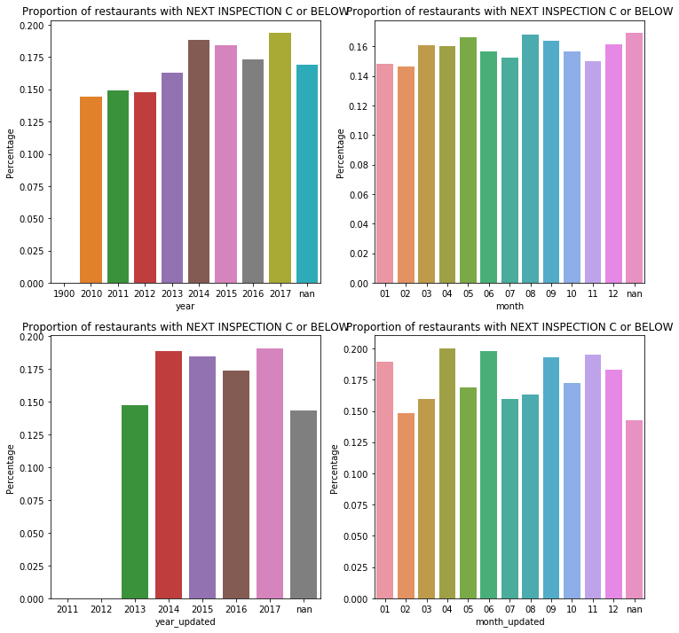

```python
fig,ax=plt.subplots(2,2,figsize=(12,12))
year = pd.DataFrame(df.groupby(df.year.fillna("N/A(Missing)")).NEXT_INSPECTION_GRADE_C_OR_BELOW.sum()
                    /df.groupby(df.year.fillna("N/A(Missing)")).NEXT_INSPECTION_GRADE_C_OR_BELOW.count()).reset_index()
sns.barplot(year.year,year.NEXT_INSPECTION_GRADE_C_OR_BELOW, ax=ax[0,0])
ax[0,0].set_ylabel("Percentage")
ax[0,0].set_title("Proportion of restaurants with NEXT INSPECTION C or BELOW")

month = pd.DataFrame(df.groupby(df.month.fillna("N/A(Missing)")).NEXT_INSPECTION_GRADE_C_OR_BELOW.sum()
                    /df.groupby(df.month.fillna("N/A(Missing)")).NEXT_INSPECTION_GRADE_C_OR_BELOW.count()).reset_index()
sns.barplot(month.month,month.NEXT_INSPECTION_GRADE_C_OR_BELOW, ax=ax[0,1])
ax[0,1].set_ylabel("Percentage")
ax[0,1].set_title("Proportion of restaurants with NEXT INSPECTION C or BELOW")

year_updated = pd.DataFrame(df.groupby(df.year_updated.fillna("N/A(Missing)")).NEXT_INSPECTION_GRADE_C_OR_BELOW.sum()
                    /df.groupby(df.year_updated.fillna("N/A(Missing)")).NEXT_INSPECTION_GRADE_C_OR_BELOW.count()).reset_index()
sns.barplot(year_updated.year_updated,year_updated.NEXT_INSPECTION_GRADE_C_OR_BELOW, ax=ax[1,0])
ax[1,0].set_ylabel("Percentage")
ax[1,0].set_title("Proportion of restaurants with NEXT INSPECTION C or BELOW")

month_updated = pd.DataFrame(df.groupby(df.month_updated.fillna("N/A(Missing)")).NEXT_INSPECTION_GRADE_C_OR_BELOW.sum()
                    /df.groupby(df.month_updated.fillna("N/A(Missing)")).NEXT_INSPECTION_GRADE_C_OR_BELOW.count()).reset_index()
sns.barplot(month_updated.month_updated,month_updated.NEXT_INSPECTION_GRADE_C_OR_BELOW, ax=ax[1,1])
ax[1,1].set_ylabel("Percentage")
ax[1,1].set_title("Proportion of restaurants with NEXT INSPECTION C or BELOW")

print("It seemed possible that inspection during Summer might result in higher number of lower grades because food can go bad easily")
print("However year and month for both 'inspection time' and 'record updated' doesn't seem highly relevant")
```

```
only 10 % of the Missing Inspection Types had low inpsection score
```

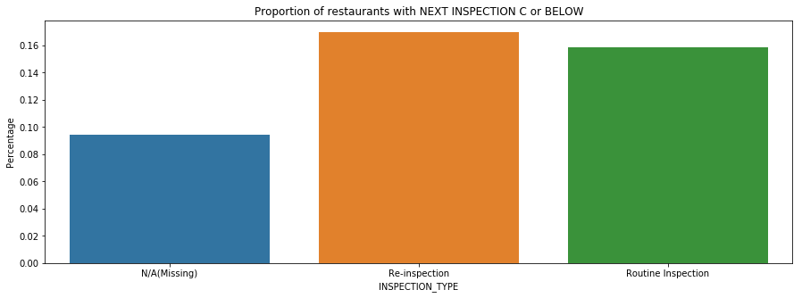

```python
temp = pd.DataFrame(df.groupby(df.INSPECTION_TYPE.fillna("N/A(Missing)")).NEXT_INSPECTION_GRADE_C_OR_BELOW.sum()
                    /df.groupby(df.INSPECTION_TYPE.fillna("N/A(Missing)")).NEXT_INSPECTION_GRADE_C_OR_BELOW.count()).reset_index()

sns.barplot(temp.INSPECTION_TYPE,temp.NEXT_INSPECTION_GRADE_C_OR_BELOW)
plt.ylabel("Percentage")
plt.title("Proportion of restaurants with NEXT INSPECTION C or BELOW")

print("only 10 % of the Missing Inspection Types had low inpsection score ")
feature_selection.append('INSPECTION_TYPE')
```

### Violation

```python
df.FIRST_VIOLATION_TYPE.value_counts()
```

```
Critical                  7195
Major                     6740
Non-Major                 1589
Imminent Health Hazard       3
Name: FIRST_VIOLATION_TYPE, dtype: int64
```

```python
df.SECOND_VIOLATION_TYPE.value_counts()
```

```
Major                     7909
Non-Major                 4507
Critical                  2985
Imminent Health Hazard       5
Name: SECOND_VIOLATION_TYPE, dtype: int64
```

```python
df.THIRD_VIOLATION_TYPE.value_counts()
```

```
Major                     7310
Non-Major                 7286
Critical                   867
Imminent Health Hazard      37
Name: THIRD_VIOLATION_TYPE, dtype: int64
```

```
Text(0,0.5,'counts')
```

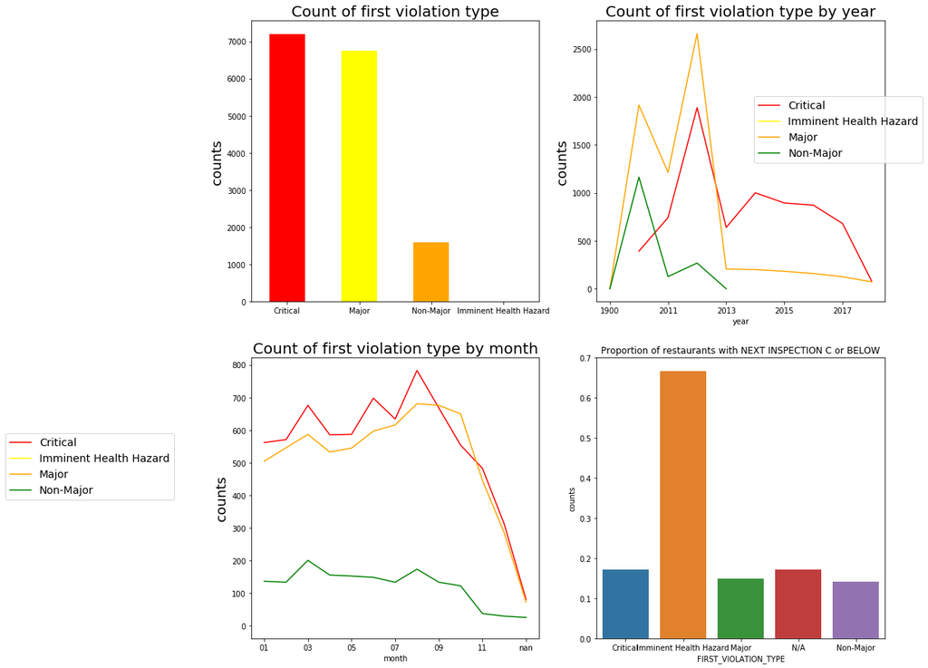

```python
# First Violation

fig,ax=plt.subplots(2,2,figsize=(15,15))
df.FIRST_VIOLATION_TYPE.value_counts().plot(kind='bar',color=['red','yellow','orange','green'],ax=ax[0,0])
ax[0,0].tick_params(axis='x',labelrotation=360)
ax[0,0].set_title("Count of first violation type",size=20)
ax[0,0].set_ylabel('counts',size=18)


df.groupby(['year','FIRST_VIOLATION_TYPE'])['RESTAURANT_SERIAL_NUMBER'].agg('count').unstack('FIRST_VIOLATION_TYPE').plot(ax=ax[0,1],color=['red','yellow','orange','green'])
ax[0,1].legend(loc=0, ncol=1, fontsize=14,bbox_to_anchor=(1.15,0.75))
ax[0,1].set_title("Count of first violation type by year",size=20)
ax[0,1].set_ylabel('counts',size=18)

df.groupby(['month','FIRST_VIOLATION_TYPE'])['RESTAURANT_SERIAL_NUMBER'].agg('count').unstack('FIRST_VIOLATION_TYPE').plot(ax=ax[1,0],color=['red','yellow','orange','green'])
ax[1,0].legend(loc=0, ncol=1, fontsize=14,bbox_to_anchor=(-0.25,0.75))
ax[1,0].set_title("Count of first violation type by month",size=20)
ax[1,0].set_ylabel('counts',size=18)

first_violation_type = pd.DataFrame(df.groupby(df.FIRST_VIOLATION_TYPE.fillna('N/A')).NEXT_INSPECTION_GRADE_C_OR_BELOW.sum()
                    /df.groupby(df.FIRST_VIOLATION_TYPE.fillna('N/A')).NEXT_INSPECTION_GRADE_C_OR_BELOW.count()).reset_index()

sns.barplot(first_violation_type.FIRST_VIOLATION_TYPE,first_violation_type.NEXT_INSPECTION_GRADE_C_OR_BELOW)
plt.ylabel("Percentage")
plt.title("Proportion of restaurants with NEXT INSPECTION C or BELOW")
ax[1,1].set_ylabel('counts',size=10)
```

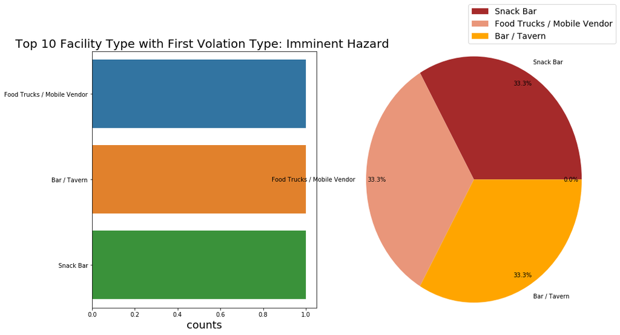

```python
df_first_hazard=df[df.FIRST_VIOLATION_TYPE == 'Imminent Health Hazard']
df_first_hazard.head()

fig,ax=plt.subplots(1,2,figsize=(15,8))
sns.barplot(x=df_first_hazard['RESTAURANT_CATEGORY'].value_counts()[:10],y=df_first_hazard['RESTAURANT_CATEGORY'].value_counts()[:10].index,ax=ax[0])
ax[0].set_title("Top 10 Facility Type with First Volation Type: Imminent Hazard ",size=20)
ax[0].set_xlabel('counts',size=18)


count=df_first_hazard.groupby(['RESTAURANT_CATEGORY'])['RESTAURANT_SERIAL_NUMBER'].agg('count').sort_values(ascending=False)
groups=list(df_first_hazard.groupby(['RESTAURANT_CATEGORY'])['RESTAURANT_SERIAL_NUMBER'].agg('count').sort_values(ascending=False).index[:10])
counts=list(count[:10])
counts.append(count.agg(sum)-count[:10].agg('sum'))
groups.append('Other')
type_dict=pd.DataFrame({"group":groups,"counts":counts})
clr1=('brown','darksalmon','orange','hotpink','cadetblue','purple','red','gold','forestgreen','blue','plum')
type_dict.plot(kind='pie', y='counts', labels=groups,colors=clr1,autopct='%1.1f%%', pctdistance=0.9, radius=1.2,ax=ax[1])
ax[1].set_ylabel('')
ax[1].legend(loc=0, ncol=1, fontsize=14,bbox_to_anchor=(1.15,1.2))
```

```
Text(0,0.5,'counts')
```

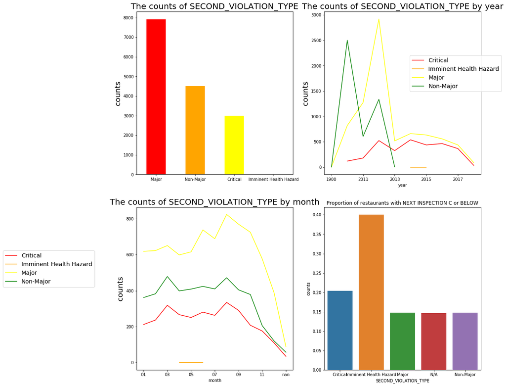

```python
# Second Violation

fig,ax=plt.subplots(2,2,figsize=(15,16))
df.SECOND_VIOLATION_TYPE.value_counts().plot(kind='bar',color=['red','orange','yellow','green'],ax=ax[0,0])
ax[0,0].tick_params(axis='x',labelrotation=360)
ax[0,0].set_title("The counts of SECOND_VIOLATION_TYPE",size=20)
ax[0,0].set_ylabel('counts',size=18)


df.groupby(['year','SECOND_VIOLATION_TYPE'])['RESTAURANT_SERIAL_NUMBER'].agg('count').unstack('SECOND_VIOLATION_TYPE').plot(ax=ax[0,1],color=['red','orange', 'yellow','green'])
ax[0,1].legend(loc=0, ncol=1, fontsize=14,bbox_to_anchor=(1.15,0.75))
ax[0,1].set_title("The counts of SECOND_VIOLATION_TYPE by year",size=20)
ax[0,1].set_ylabel('counts',size=18)

df.groupby(['month','SECOND_VIOLATION_TYPE'])['RESTAURANT_SERIAL_NUMBER'].agg('count').unstack('SECOND_VIOLATION_TYPE').plot(ax=ax[1,0],color=['red','orange','yellow','green'])
ax[1,0].legend(loc=0, ncol=1, fontsize=14,bbox_to_anchor=(-0.25,0.75))
ax[1,0].set_title("The counts of SECOND_VIOLATION_TYPE by month",size=20)
ax[1,0].set_ylabel('counts',size=18)

second_violation_type = pd.DataFrame(df.groupby(df.SECOND_VIOLATION_TYPE.fillna('N/A')).NEXT_INSPECTION_GRADE_C_OR_BELOW.sum()
                    /df.groupby(df.SECOND_VIOLATION_TYPE.fillna('N/A')).NEXT_INSPECTION_GRADE_C_OR_BELOW.count()).reset_index()

sns.barplot(second_violation_type.SECOND_VIOLATION_TYPE,second_violation_type.NEXT_INSPECTION_GRADE_C_OR_BELOW)
plt.ylabel("Percentage")
plt.title("Proportion of restaurants with NEXT INSPECTION C or BELOW")
ax[1,1].set_ylabel('counts',size=10)
```

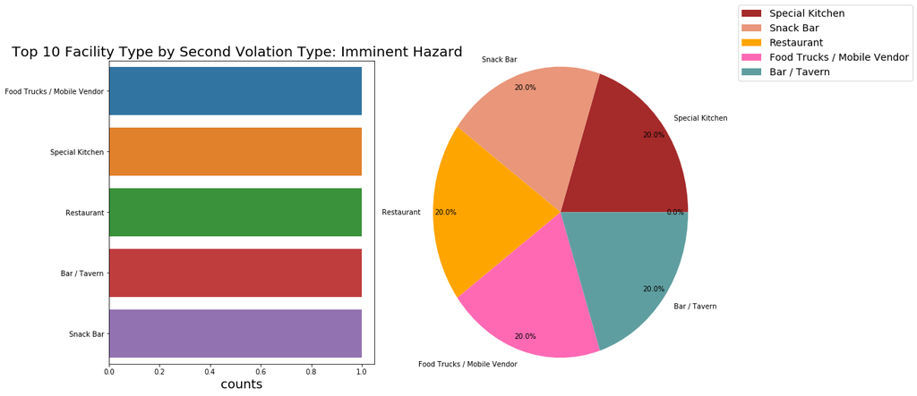

```python
df_second_hazard=df[df.SECOND_VIOLATION_TYPE == 'Imminent Health Hazard']
df_second_hazard.head()

fig,ax=plt.subplots(1,2,figsize=(15,8))
sns.barplot(x=df_second_hazard['RESTAURANT_CATEGORY'].value_counts()[:10],y=df_second_hazard['RESTAURANT_CATEGORY'].value_counts()[:10].index,ax=ax[0])
ax[0].set_title("Top 10 Facility Type by Second Volation Type: Imminent Hazard  ",size=20)
ax[0].set_xlabel('counts',size=18)


count=df_second_hazard.groupby(['RESTAURANT_CATEGORY'])['RESTAURANT_SERIAL_NUMBER'].agg('count').sort_values(ascending=False)
groups=list(df_second_hazard.groupby(['RESTAURANT_CATEGORY'])['RESTAURANT_SERIAL_NUMBER'].agg('count').sort_values(ascending=False).index[:10])
counts=list(count[:10])
counts.append(count.agg(sum)-count[:10].agg('sum'))
groups.append('Other')
type_dict=pd.DataFrame({"group":groups,"counts":counts})
clr1=('brown','darksalmon','orange','hotpink','cadetblue','purple','red','gold','forestgreen','blue','plum')
type_dict.plot(kind='pie', y='counts', labels=groups,colors=clr1,autopct='%1.1f%%', pctdistance=0.9, radius=1.2,ax=ax[1])
ax[1].set_ylabel('')
ax[1].legend(loc=0, ncol=1, fontsize=14,bbox_to_anchor=(1.15,1.2))
```

```
Text(0,0.5,'counts')
```

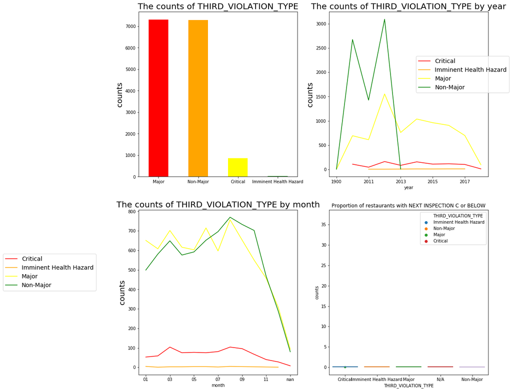

```python
# Third Violation

fig,ax=plt.subplots(2,2,figsize=(15,16))
df.THIRD_VIOLATION_TYPE.value_counts().plot(kind='bar',color=['red','orange','yellow','green'],ax=ax[0,0])
ax[0,0].tick_params(axis='x',labelrotation=360)
ax[0,0].set_title("The counts of THIRD_VIOLATION_TYPE",size=20)
ax[0,0].set_ylabel('counts',size=18)


df.groupby(['year','THIRD_VIOLATION_TYPE'])['RESTAURANT_SERIAL_NUMBER'].agg('count').unstack('THIRD_VIOLATION_TYPE').plot(ax=ax[0,1],color=['red','orange', 'yellow','green'])
ax[0,1].legend(loc=0, ncol=1, fontsize=14,bbox_to_anchor=(1.15,0.75))
ax[0,1].set_title("The counts of THIRD_VIOLATION_TYPE by year",size=20)
ax[0,1].set_ylabel('counts',size=18)

df.groupby(['month','THIRD_VIOLATION_TYPE'])['RESTAURANT_SERIAL_NUMBER'].agg('count').unstack('THIRD_VIOLATION_TYPE').plot(ax=ax[1,0],color=['red','orange','yellow','green'])
ax[1,0].legend(loc=0, ncol=1, fontsize=14,bbox_to_anchor=(-0.25,0.75))
ax[1,0].set_title("The counts of THIRD_VIOLATION_TYPE by month",size=20)
ax[1,0].set_ylabel('counts',size=18)

sns.scatterplot(x='Longitude',y='Latitude',hue='THIRD_VIOLATION_TYPE' ,data=df, ax=ax[1,1])
ax[1,1].set_title("The distribution of inspections by risk",size=20)
ax[1,1].set_xlabel('Longitude')
ax[1,1].set_ylabel('LATITUDE')

third_violation_type = pd.DataFrame(df.groupby(df.THIRD_VIOLATION_TYPE.fillna('N/A')).NEXT_INSPECTION_GRADE_C_OR_BELOW.sum()
                    /df.groupby(df.THIRD_VIOLATION_TYPE.fillna('N/A')).NEXT_INSPECTION_GRADE_C_OR_BELOW.count()).reset_index()

sns.barplot(third_violation_type.THIRD_VIOLATION_TYPE,third_violation_type.NEXT_INSPECTION_GRADE_C_OR_BELOW)
plt.ylabel("Percentage")
plt.title("Proportion of restaurants with NEXT INSPECTION C or BELOW")
ax[1,1].set_ylabel('counts',size=10)
```

```
The new variable will help us better treat the VIOLATION RAW column
```

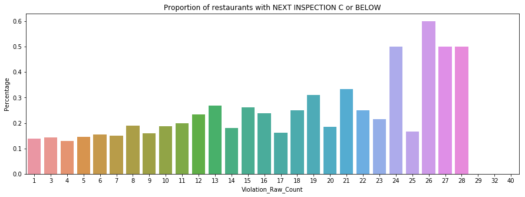

```python
# Make another variable from VIOLATION RAW column which shows
df['Violation_Raw_Count'] = df.VIOLATIONS_RAW.apply(lambda x:len(str(x).split(',')))

Violation_Raw_Count = pd.DataFrame(df.groupby(df.Violation_Raw_Count).NEXT_INSPECTION_GRADE_C_OR_BELOW.sum()
                    /df.groupby(df.Violation_Raw_Count).NEXT_INSPECTION_GRADE_C_OR_BELOW.count()).reset_index()

sns.barplot(Violation_Raw_Count.Violation_Raw_Count,Violation_Raw_Count.NEXT_INSPECTION_GRADE_C_OR_BELOW)
plt.ylabel("Percentage")
plt.title("Proportion of restaurants with NEXT INSPECTION C or BELOW")

print("The new variable will help us better treat the VIOLATION RAW column")
```

```
Text(0.5,1,'Proportion of restaurants with NEXT INSPECTION C or BELOW')
```

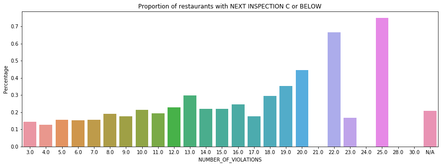

```python
number_of_violations = pd.DataFrame(df.groupby(df.NUMBER_OF_VIOLATIONS.fillna('N/A')).NEXT_INSPECTION_GRADE_C_OR_BELOW.sum()
                    /df.groupby(df.NUMBER_OF_VIOLATIONS.fillna('N/A')).NEXT_INSPECTION_GRADE_C_OR_BELOW.count()).reset_index()

sns.barplot(number_of_violations.NUMBER_OF_VIOLATIONS,number_of_violations.NEXT_INSPECTION_GRADE_C_OR_BELOW)
plt.ylabel("Percentage")
plt.title("Proportion of restaurants with NEXT INSPECTION C or BELOW")
```

```python
print("Violation types and number of violations must be encluded in the predictor variable")
print("Violation type null has similar number of low inspections grades with Non-Major and Major")
feature_selection = feature_selection + ['NUMBER_OF_VIOLATION','FIRST_VIOLATION_TYPE','SECOND_VIOLATION_TYPE','THIRD_VIOLATION_TYPE','Violation_Raw_Count']
```

```
Violation types and number of violations must be encluded in the predictor variable
Violation type null has similar number of low inspections grades with Non-Major and Major
```

### External Data

```python
ex = pd.read_csv('/Users/dunyenghuh/Downloads/Restaurant_Inspection_Violation_Codes.csv')
print("The above dataset helps understanding of the meaning of the violation_ids / how serious each record is ")
print("Source: https://opendataportal-lasvegas.opendata.arcgis.com/datasets/restaurant-inspection-violation-codes")

# since violation_id >300 shows Imminnent Health Hazard, change the value from 0 to 20 to represent the seriousness
violation_dct = {ex.Violation_ID[i].astype(int): ex.Violation_Demerits[i].astype(int) for i in range(len(ex.Violation_ID))}
for i in range(300,311):
    violation_dct[i] = 20
```

```
The above dataset helps understanding of the meaning of the violation_ids / how serious each record is
Source: https://opendataportal-lasvegas.opendata.arcgis.com/datasets/restaurant-inspection-violation-codes
```

```python
df[['FIRST_VIOLATION','SECOND_VIOLATION','THIRD_VIOLATION']] = df[['FIRST_VIOLATION','SECOND_VIOLATION','THIRD_VIOLATION']].fillna(0).astype(int)
df[['FIRST_VIOLATION_num','SECOND_VIOLATION_num','THIRD_VIOLATION_num']] = df[['FIRST_VIOLATION','SECOND_VIOLATION','THIRD_VIOLATION']].replace(violation_dct)

# by cross checking the numbers, we can assume how the violation types should be numerically converted.
violation_scale = {"Imminent Health Hazard":20, "Critical":6,"Major":3,"Non-Major":1}
```

## Feature Selection

```python
feature_selection = ['CITY','INSPECTION_TYPE','RESTAURANT_CATEGORY', 'CURRENT_GRADE', 'NUMBER_OF_VIOLATIONS',
                    'CURRENT_DEMERITS','INSPECTION_DEMERITS','FIRST_VIOLATION_TYPE','SECOND_VIOLATION_TYPE','THIRD_VIOLATION_TYPE']
```

```python
test = pd.read_csv('/Users/dunyenghuh/Downloads/TEST_SET.csv')
train = pd.read_csv('/Users/dunyenghuh/Downloads/TRAIN_SET.csv')


ntrain = train.shape[0]
ntest = test.shape[0]
y_train = train.NEXT_INSPECTION_GRADE_C_OR_BELOW
train = train.drop(columns=['NEXT_INSPECTION_GRADE_C_OR_BELOW'])
train.head()
all_data= pd.concat([train,test])
####

data = all_data[feature_selection]
data.head()
# As I am not certain about the values of CURRENT GRADE, I will one-hot encode these columns

oh_encode = ['CITY','INSPECTION_TYPE','RESTAURANT_CATEGORY', 'CURRENT_GRADE']
# for OH_encode columns, I will be imputing the null values with 'N/A' for now
data[oh_encode]=data[oh_encode].fillna('N/A')

# for 'Number of violations', the proportion of low inspection grade was similar to that of value 8-9 and 15-16.
# looking at the distribution of the data, the data is right-skewed. Thus, I will impute the missing value with 8-9, which we see more often
data['NUMBER_OF_VIOLATIONS'] = data['NUMBER_OF_VIOLATIONS'].fillna(8)
#data['NUMBER_OF_VIOLATIONS'] = data['NUMBER_OF_VIOLATIONS'].fillna(data['NUMBER_OF_VIOLATIONS'].median())


# for 'CURRENT_DEMERITS' and 'INSPECTION_DEMERITS', the proportion of low inspection grade is same as 11 and 14 respectively
data['CURRENT_DEMERITS'] = data['CURRENT_DEMERITS'].fillna(11)
data['INSPECTION_DEMERITS'] = data['INSPECTION_DEMERITS'].fillna(14)
#data['CURRENT_DEMERITS'] = data['CURRENT_DEMERITS'].fillna(data['CURRENT_DEMERITS'].median())
#data['INSPECTION_DEMERITS'] = data['INSPECTION_DEMERITS'].fillna(data['INSPECTION_DEMERITS'].median())


violation_scale = {"Imminent Health Hazard":20, "Critical":6,"Major":3,"Non-Major":1}
data[['FIRST_VIOLATION_TYPE','SECOND_VIOLATION_TYPE','THIRD_VIOLATION_TYPE']] = data[['FIRST_VIOLATION_TYPE','SECOND_VIOLATION_TYPE','THIRD_VIOLATION_TYPE']].replace(violation_scale, regex=True)
# for the 3 columns above, we saw that number of low inspection grade for null values were not very different from either 'Major' or 'Non Major'
# thus I will impute the null values with the median for each columns
data.FIRST_VIOLATION_TYPE=data.FIRST_VIOLATION_TYPE.fillna(data.FIRST_VIOLATION_TYPE.median())
data.SECOND_VIOLATION_TYPE=data.SECOND_VIOLATION_TYPE.fillna(data.SECOND_VIOLATION_TYPE.median())
data.THIRD_VIOLATION_TYPE=data.THIRD_VIOLATION_TYPE.fillna(data.THIRD_VIOLATION_TYPE.median())

# new column introduced to count the violations
data['Violation_Raw_Count'] = all_data.VIOLATIONS_RAW.apply(lambda x:len(str(x).split(',')))


data['EMPLOYEE_COUNT'] = all_data['EMPLOYEE_COUNT'].fillna(all_data['EMPLOYEE_COUNT'].median())
data['MEDIAN_EMPLOYEE_AGE'] = all_data['MEDIAN_EMPLOYEE_AGE'].fillna(all_data['MEDIAN_EMPLOYEE_AGE'].median())
data['MEDIAN_EMPLOYEE_TENURE'] = all_data['MEDIAN_EMPLOYEE_TENURE'].fillna(all_data['MEDIAN_EMPLOYEE_TENURE'].median())

data.head(10)
```

[output not shown]

|  | CITY | INSPECTION_TYPE | RESTAURANT_CATEGORY | CURRENT_GRADE | NUMBER_OF_VIOLATIONS | CURRENT_DEMERITS | INSPECTION_DEMERITS | FIRST_VIOLATION_TYPE | SECOND_VIOLATION_TYPE | THIRD_VIOLATION_TYPE | Violation_Raw_Count | EMPLOYEE_COUNT | MEDIAN_EMPLOYEE_AGE | MEDIAN_EMPLOYEE_TENURE |
| --- | --- | --- | --- | --- | --- | --- | --- | --- | --- | --- | --- | --- | --- | --- |
| 0 | Las Vegas | Routine Inspection | Snack Bar | A | 4.0 | 0.0 | 11.0 | 6 | 3.0 | 20.0 | 5 | 25.0 | 27.959983 | 13.004886 |
| 1 | Las Vegas | Routine Inspection | Restaurant | A | 5.0 | 3.0 | 9.0 | 3 | 3.0 | 3.0 | 5 | 7.0 | 27.719365 | 3.922086 |
| 2 | Las Vegas | Routine Inspection | Restaurant | A | 3.0 | 8.0 | 9.0 | 6 | 3.0 | 3.0 | 3 | 23.0 | 26.442637 | 10.312777 |
| 3 | Las Vegas | Routine Inspection | Elementary School Kitchen | A | 3.0 | 0.0 | 5.0 | 3 | 3.0 | 3.0 | 3 | 14.0 | 33.988293 | 4.163975 |
| 4 | Las Vegas | Routine Inspection | Bar / Tavern | A | 8.0 | 0.0 | 5.0 | 3 | 3.0 | 3.0 | 3 | 10.0 | 21.980282 | 13.462786 |
| 5 | Las Vegas | Routine Inspection | Bar / Tavern | A | 7.0 | 3.0 | 17.0 | 6 | 3.0 | 3.0 | 8 | 43.0 | 25.947206 | 3.839934 |
| 6 | Las Vegas | Routine Inspection | Restaurant | A | 4.0 | 6.0 | 10.0 | 3 | 3.0 | 3.0 | 4 | 10.0 | 32.910780 | 2.673364 |
| 7 | Las Vegas | Routine Inspection | Restaurant | A | 12.0 | 0.0 | 20.0 | 6 | 3.0 | 3.0 | 15 | 14.0 | 34.199497 | 4.766880 |
| 8 | Boulder City | Routine Inspection | Restaurant | A | 3.0 | 3.0 | 7.0 | 3 | 3.0 | 3.0 | 3 | 34.0 | 33.321615 | 6.256492 |
| 9 | Las Vegas | Routine Inspection | Pantry | A | 5.0 | 9.0 | 9.0 | 3 | 3.0 | 3.0 | 5 | 24.0 | 23.007905 | 2.450029 |

```python
OH_encoder = OneHotEncoder(handle_unknown = 'ignore', sparse = False)

data_OH = pd.DataFrame(OH_encoder.fit_transform(data[oh_encode]))

#test_x_OH = pd.DataFrame(OH_encoder.transform(test_x_oh))
data_OH.index =  data[oh_encode].index
data_OH.head()
```

|  | 0 | 1 | 2 | 3 | 4 | 5 | 6 | 7 | 8 | 9 | ... | 52 | 53 | 54 | 55 | 56 | 57 | 58 | 59 | 60 | 61 |
| --- | --- | --- | --- | --- | --- | --- | --- | --- | --- | --- | --- | --- | --- | --- | --- | --- | --- | --- | --- | --- | --- |
| 0 | 0.0 | 0.0 | 0.0 | 0.0 | 0.0 | 0.0 | 0.0 | 0.0 | 0.0 | 0.0 | ... | 1.0 | 0.0 | 0.0 | 1.0 | 0.0 | 0.0 | 0.0 | 0.0 | 0.0 | 0.0 |
| 1 | 0.0 | 0.0 | 0.0 | 0.0 | 0.0 | 0.0 | 0.0 | 0.0 | 0.0 | 0.0 | ... | 0.0 | 0.0 | 0.0 | 1.0 | 0.0 | 0.0 | 0.0 | 0.0 | 0.0 | 0.0 |
| 2 | 0.0 | 0.0 | 0.0 | 0.0 | 0.0 | 0.0 | 0.0 | 0.0 | 0.0 | 0.0 | ... | 0.0 | 0.0 | 0.0 | 1.0 | 0.0 | 0.0 | 0.0 | 0.0 | 0.0 | 0.0 |
| 3 | 0.0 | 0.0 | 0.0 | 0.0 | 0.0 | 0.0 | 0.0 | 0.0 | 0.0 | 0.0 | ... | 0.0 | 0.0 | 0.0 | 1.0 | 0.0 | 0.0 | 0.0 | 0.0 | 0.0 | 0.0 |
| 4 | 0.0 | 0.0 | 0.0 | 0.0 | 0.0 | 0.0 | 0.0 | 0.0 | 0.0 | 0.0 | ... | 0.0 | 0.0 | 0.0 | 1.0 | 0.0 | 0.0 | 0.0 | 0.0 | 0.0 | 0.0 |

5 rows × 62 columns

```python
data_non_OH = data[[ 'CURRENT_DEMERITS', 'INSPECTION_DEMERITS','NUMBER_OF_VIOLATIONS', 'FIRST_VIOLATION_TYPE',
                    'SECOND_VIOLATION_TYPE','THIRD_VIOLATION_TYPE','Violation_Raw_Count'
                 ,'EMPLOYEE_COUNT','MEDIAN_EMPLOYEE_AGE','MEDIAN_EMPLOYEE_TENURE']]

temp = pd.concat([data_non_OH, data_OH], axis =1)
temp['y'] = df.NEXT_INSPECTION_GRADE_C_OR_BELOW

new_df = temp[:ntrain]
new_test = temp.tail(ntest)

new_df = new_df[new_df['y'].notna()]
```

```python
new_df.shape
```

```
(15633, 73)
```

## Model Building / Accuracy

Although widely used, classification accuracy is almost universally inappropriate for imbalanced classification. The reason is, a high accuracy (or low error) is achievable by a no skill model that only predicts the majority class.

Alternatively, we can look at Precision-Recall Metrics (Precision, Recall, F1 score)

```python
y =  new_df.y
new_df = new_df.drop(columns = 'y')

train_x, test_x, train_y, test_y = train_test_split(new_df, y)
```

```
1.0
Accuracy:  0.8434382194934766
              precision    recall  f1-score   support

         0.0       0.85      1.00      0.91      3304
         1.0       0.29      0.01      0.02       605

    accuracy                           0.84      3909
   macro avg       0.57      0.50      0.47      3909
weighted avg       0.76      0.84      0.78      3909
```

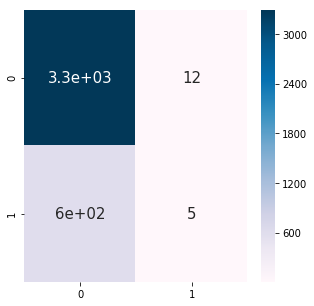

```python
from sklearn.ensemble import RandomForestClassifier
from sklearn.metrics import accuracy_score

from sklearn.metrics import confusion_matrix
from sklearn.metrics import classification_report

#class_weight hyperparameter is used to deal with unbalanced data
classifier = RandomForestClassifier(class_weight='balanced')
classifier.fit(train_x, train_y)
print(classifier.score(train_x,train_y))
pred = classifier.predict(test_x)
print("Accuracy: ",accuracy_score(test_y, pred))

cm = confusion_matrix(test_y, pred)
plt.rcParams['figure.figsize'] = (5, 5)
sns.heatmap(cm, annot = True, annot_kws = {'size':15}, cmap = 'PuBu')

# classification report
cr = classification_report(test_y, pred)
print(cr)
```

```
0.8101499423298731
0.8053969901401141
              precision    recall  f1-score   support

         0.0       0.84      0.95      0.89      4844
         1.0       0.21      0.07      0.11       937

    accuracy                           0.81      5781
   macro avg       0.53      0.51      0.50      5781
weighted avg       0.74      0.81      0.76      5781
```

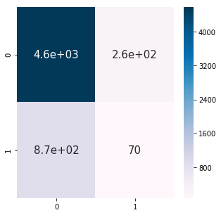

```python
from sklearn.naive_bayes import MultinomialNB

classifier = MultinomialNB()
classifier.fit(train_x, train_y)
print(classifier.score(train_x,train_y))
pred = classifier.predict(test_x)
print(accuracy_score(test_y, pred))

# cofusion matrix
cm = confusion_matrix(test_y, pred)
plt.rcParams['figure.figsize'] = (5, 5)
sns.heatmap(cm, annot = True, annot_kws = {'size':15}, cmap = 'PuBu')

# classification report
cr = classification_report(test_y, pred)
print(cr)
```

```
0.18108154213578984
0.1780506523407521
              precision    recall  f1-score   support

         0.0       0.88      0.03      0.06      3295
         1.0       0.16      0.98      0.27       614

    accuracy                           0.18      3909
   macro avg       0.52      0.50      0.16      3909
weighted avg       0.77      0.18      0.09      3909
```

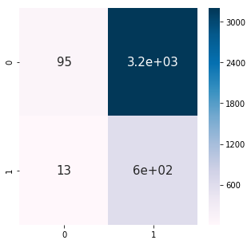

```python
from sklearn.naive_bayes import GaussianNB
classifier = GaussianNB()

classifier.fit(train_x, train_y)
print(classifier.score(train_x,train_y))
pred = classifier.predict(test_x)
print(accuracy_score(test_y, pred))

# cofusion matrix
cm = confusion_matrix(test_y, pred)
plt.rcParams['figure.figsize'] = (5, 5)
sns.heatmap(cm, annot = True, annot_kws = {'size':15}, cmap = 'PuBu')

# classification report
cr = classification_report(test_y, pred)
print(cr)
```

```
1.0
0.7209825289742259
              precision    recall  f1-score   support

         0.0       0.84      0.82      0.83      4844
         1.0       0.17      0.19      0.18       937

    accuracy                           0.72      5781
   macro avg       0.50      0.51      0.50      5781
weighted avg       0.73      0.72      0.73      5781
```

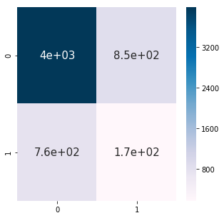

```python
from sklearn.tree import DecisionTreeClassifier
classifier = DecisionTreeClassifier()

classifier.fit(train_x, train_y)
print(classifier.score(train_x,train_y))
pred = classifier.predict(test_x)
print(accuracy_score(test_y, pred))

# cofusion matrix
cm = confusion_matrix(test_y, pred)
plt.rcParams['figure.figsize'] = (5, 5)
sns.heatmap(cm, annot = True, annot_kws = {'size':15}, cmap = 'PuBu')

# classification report
cr = classification_report(test_y, pred)
print(cr)
```

```
0.8452289588129956
0.8452289588129956
              precision    recall  f1-score   support

         0.0       0.85      1.00      0.92      3304
         1.0       0.00      0.00      0.00       605

    accuracy                           0.85      3909
   macro avg       0.42      0.50      0.46      3909
weighted avg       0.71      0.85      0.77      3909
```

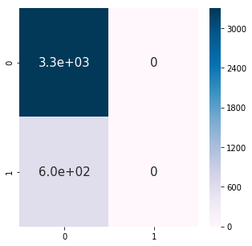

```python
from sklearn.neighbors import KNeighborsClassifier

classifier = KNeighborsClassifier(n_neighbors = 105)
classifier.fit(train_x, train_y)
print(classifier.score(test_x, test_y))
pred = classifier.predict(test_x)
print(accuracy_score(test_y, pred))

# cofusion matrix
cm = confusion_matrix(test_y, pred)
plt.rcParams['figure.figsize'] = (5, 5)
sns.heatmap(cm, annot = True, annot_kws = {'size':15}, cmap = 'PuBu')

# classification report
cr = classification_report(test_y, pred)
print(cr)
```

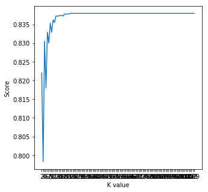

```
Maximum KNN Score is 83.79%
```

```python
scoreList = []
for i in range(2,110):
    knn2 = KNeighborsClassifier(n_neighbors = i)  # n_neighbors means k
    knn2.fit(train_x, train_y)
    scoreList.append(knn2.score(test_x, test_y))

plt.plot(range(2,110), scoreList)
plt.xticks(np.arange(2,110,1))
plt.xlabel("K value")
plt.ylabel("Score")
plt.show()

acc = max(scoreList)*100
print("Maximum KNN Score is {:.2f}%".format(acc))
```

```
0.8407540088706926
0.8452289588129956
              precision    recall  f1-score   support

         0.0       0.85      1.00      0.92      3304
         1.0       0.00      0.00      0.00       605

    accuracy                           0.85      3909
   macro avg       0.42      0.50      0.46      3909
weighted avg       0.71      0.85      0.77      3909
```

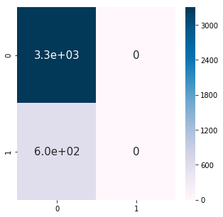

```python
from sklearn.svm import SVC
svm = SVC(random_state = 1)
svm.fit(train_x, train_y)
print(svm.score(train_x,train_y))
pred = svm.predict(test_x)
print(accuracy_score(test_y, pred))

# cofusion matrix
cm = confusion_matrix(test_y, pred)
plt.rcParams['figure.figsize'] = (5, 5)
sns.heatmap(cm, annot = True, annot_kws = {'size':15}, cmap = 'PuBu')

# classification report
cr = classification_report(test_y, pred)
print(cr)
```

```python
from sklearn.model_selection import KFold, cross_val_score, train_test_split, RepeatedKFold, StratifiedKFold

def accuracy_cv(model):
    kf = RepeatedKFold(n_splits=5, n_repeats=3, random_state=1)
    scv = StratifiedKFold(n_splits=5)
    accuracy= cross_val_score(model, new_df, y, scoring="accuracy", cv = scv)
    return(accuracy)

metric_names = ['f1', 'roc_auc', 'average_precision', 'accuracy', 'precision', 'recall']
scores_df = pd.DataFrame(index=metric_names, columns=['Stratified-CV']) # to store the scores
scv = StratifiedKFold(n_splits=5)
```

```python
RandomForest = make_pipeline(RandomForestClassifier(class_weight='balanced'))
score = accuracy_cv(RandomForest)
print("\nRandom Forrest accuracy score: {:.4f} ({:.4f})\n".format(score.mean(), score.std()))

clf = RandomForestClassifier()
for metric in metric_names:
    score = cross_val_score(clf, new_df, y, scoring=metric, cv=scv).mean()
    scores_df.loc[metric] = [score]
scores_df
```

```
Random Forrest accuracy score: 0.8401 (0.0007)
```

|  | Stratified-CV |
| --- | --- |
| f1 | 0.0109721 |
| roc_auc | 0.543895 |
| average_precision | 0.182023 |
| accuracy | 0.839826 |
| precision | 0.214603 |
| recall | 0.0076874 |

```python
MNB = make_pipeline(MultinomialNB())
score = accuracy_cv(MNB)
print("\nMNB score: {:.4f} ({:.4f})\n".format(score.mean(), score.std()))

clf = MultinomialNB()
for metric in metric_names:
    score = cross_val_score(clf, new_df, y, scoring=metric, cv=scv).mean()
    scores_df.loc[metric] = [score]
scores_df
```

```
MNB score: 0.7931 (0.0077)
```

|  | Stratified-CV |
| --- | --- |
| f1 | 0.178443 |
| roc_auc | 0.55914 |
| average_precision | 0.201662 |
| accuracy | 0.79313 |
| precision | 0.241091 |
| recall | 0.141994 |

```python
SVM = make_pipeline(SVC(random_state = 1))
score = accuracy_cv(SVM)
print("\nSVC score: {:.4f} ({:.4f})\n".format(score.mean(), score.std()))

clf = SVC(random_state = 1)
for metric in metric_names:
    score = cross_val_score(clf, new_df, y, scoring=metric, cv=scv).mean()
    scores_df.loc[metric] = [score]
scores_df
```

```
SVC score: 0.8419 (0.0001)
```

|  | Stratified-CV |
| --- | --- |
| f1 | 0 |
| roc_auc | 0.511666 |
| average_precision | 0.177822 |
| accuracy | 0.841873 |
| precision | 0 |
| recall | 0 |

```python
from sklearn.linear_model import LogisticRegression
logit = make_pipeline(LogisticRegression())
score = accuracy_cv(logit)
print("\nLogisticRegression score: {:.4f} ({:.4f})\n".format(score.mean(), score.std()))

clf = LogisticRegression()
for metric in metric_names:
    score = cross_val_score(clf, new_df, y, scoring=metric, cv=scv).mean()
    scores_df.loc[metric] = [score]
scores_df
```

[output not shown]

```
LogisticRegression score: 0.8418 (0.0002)
```

[output not shown]

[output cut: 193 more lines]

[output not shown]

|  | Stratified-CV |
| --- | --- |
| f1 | 0 |
| roc_auc | 0.571031 |
| average_precision | 0.203559 |
| accuracy | 0.841809 |
| precision | 0 |
| recall | 0 |

```python
xgb = make_pipeline(XGBClassifier())
score = accuracy_cv(xgb)
print("\nLXGBClassifier score: {:.4f} ({:.4f})\n".format(score.mean(), score.std()))

clf = XGBClassifier()
for metric in metric_names:
    score = cross_val_score(clf, new_df, y, scoring=metric, cv=scv).mean()
    scores_df.loc[metric] = [score]
scores_df
```

```
LXGBClassifier score: 0.8364 (0.0034)
```

|  | Stratified-CV |
| --- | --- |
| f1 | 0.0354847 |
| roc_auc | 0.536712 |
| average_precision | 0.186125 |
| accuracy | 0.836372 |
| precision | 0.267367 |
| recall | 0.0190169 |

# Conclusion

In order to consider the performance of the classifier on the minority class, I will also look at ROC/AUC for final decision

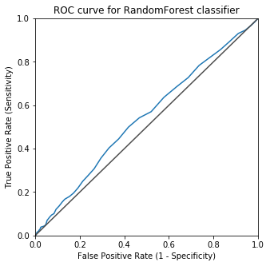

```
AUC Score : 0.5405183799251596
```

```python
from sklearn.metrics import roc_curve
from sklearn.metrics import auc

classifier = RandomForestClassifier(class_weight='balanced')
classifier.fit(train_x, train_y)
pred = classifier.predict(test_x)

y_pred_quant = classifier.predict_proba(test_x)[:, 1]
fpr, tpr, thresholds = roc_curve(test_y, y_pred_quant)

fig, ax = plt.subplots()
ax.plot(fpr, tpr)
ax.plot([0, 1], [0, 1], transform=ax.transAxes, ls="-", c=".3")
plt.xlim([0.0, 1.0])
plt.ylim([0.0, 1.0])

plt.rcParams['figure.figsize'] = (8, 8)
plt.title('ROC curve for RandomForest classifier', fontweight = 30)
plt.xlabel('False Positive Rate (1 - Specificity)')
plt.ylabel('True Positive Rate (Sensitivity)')
plt.show()


auc = auc(fpr, tpr)
print("AUC Score :", auc)
```

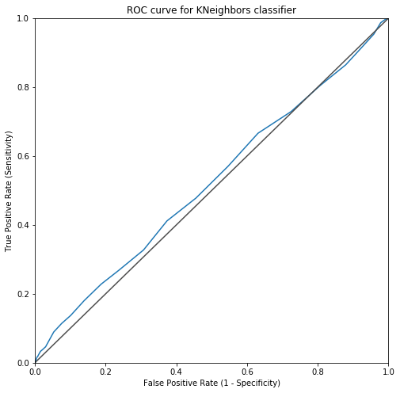

```python
classifier = KNeighborsClassifier(n_neighbors = 105)
classifier.fit(train_x, train_y)
pred = classifier.predict(test_x)

y_pred_quant = classifier.predict_proba(test_x)[:, 1]
fpr, tpr, thresholds = roc_curve(test_y, y_pred_quant)

fig, ax = plt.subplots()
ax.plot(fpr, tpr)
ax.plot([0, 1], [0, 1], transform=ax.transAxes, ls="-", c=".3")
plt.xlim([0.0, 1.0])
plt.ylim([0.0, 1.0])

plt.rcParams['figure.figsize'] = (8, 8)
plt.title('ROC curve for KNeighbors classifier', fontweight = 30)
plt.xlabel('False Positive Rate (1 - Specificity)')
plt.ylabel('True Positive Rate (Sensitivity)')
plt.show()


# auc1 = auc(fpr, tpr)
# print("AUC Score :", auc1)
```

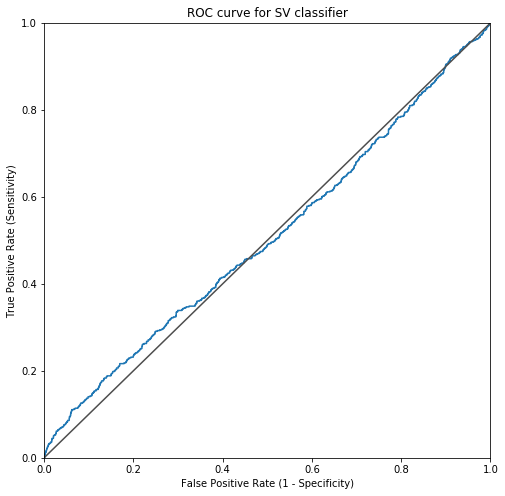

```python
svm = SVC(random_state = 1, probability=True)
svm.fit(train_x, train_y)
pred = svm.predict(test_x)
y_pred_quant = svm.predict_proba(test_x)[:, 1]
fpr, tpr, thresholds = roc_curve(test_y, y_pred_quant)

fig, ax = plt.subplots()
ax.plot(fpr, tpr)
ax.plot([0, 1], [0, 1], transform=ax.transAxes, ls="-", c=".3")
plt.xlim([0.0, 1.0])
plt.ylim([0.0, 1.0])

plt.rcParams['figure.figsize'] = (8, 8)
plt.title('ROC curve for SV classifier', fontweight = 30)
plt.xlabel('False Positive Rate (1 - Specificity)')
plt.ylabel('True Positive Rate (Sensitivity)')
plt.show()
```

Assume “the sky’s the limit” and write a one-page recommendation on how the data set could be improved. Provide at least 8-10 additional attributes and prepare to defend your choices. (It may be helpful to perform additional research online as time allows).

# Recommendation for improving the data

1. Meta Data is needed to explain the values within each of the columns listed
2. Missing values in the data needs to be addressed
3. Zipcode needs to have a uniform format
4. There are values in the VIOLATION_RAW column which does not exists in the external dataset (https://opendataportal-lasvegas.opendata.arcgis.com/datasets/restaurant-inspection-violation-codes)
5. The value for VIOLATION_RAW needs to be integers separated by comma
6. The values for certain columns are wrong. (ex. First Violation Type == 1)
7. We need few more column to understand the seriousness/ demerits of different violation types. Information can be found from the source below (https://opendataportal-lasvegas.opendata.arcgis.com/datasets/restaurant-inspection-violation-codes)
8. Columns could be formatted in more accurate data types
9. We could always use more data to provide more accurate classification

### Making Prediction with test data

```python
new_test.shape
```

```
(7505, 72)
```

```python
classifier = RandomForestClassifier(class_weight='balanced')
classifier.fit(train_x, train_y)
pred = classifier.predict(new_test)
pred
```

```
array([0., 0., 0., ..., 0., 0., 0.])
```

```python
probability = classifier.predict_proba(new_test)
probability[0].tolist()
```

```
[0.9, 0.1]
```

```python
serial_num = test['RESTAURANT_SERIAL_NUMBER']
```

```python
ans = pd.DataFrame(serial_num, columns=['RESTAURANT_SERIAL_NUMBER'])
ans['CLASSIFIER_PROBABILITY'] = [probability[i].tolist() for i in range(len(probability))]
ans['CLASSIFIER_PREDICTION'] = pred
ans
```

|  | RESTAURANT_SERIAL_NUMBER | CLASSIFIER_PROBABILITY | CLASSIFIER_PREDICTION |
| --- | --- | --- | --- |
| 0 | DA1050454 | [0.9, 0.1] | 0.0 |
| 1 | DA0986444 | [0.86, 0.14] | 0.0 |
| 2 | DA1284914 | [0.91, 0.09] | 0.0 |
| 3 | DA1281903 | [0.74, 0.26] | 0.0 |
| 4 | DA1004708 | [0.93, 0.07] | 0.0 |
| ... | ... | ... | ... |
| 7500 | DA0922689 | [0.81, 0.19] | 0.0 |
| 7501 | DA1031095 | [0.86, 0.14] | 0.0 |
| 7502 | DA0633450 | [0.79, 0.21] | 0.0 |
| 7503 | DA0998980 | [0.84, 0.16] | 0.0 |
| 7504 | DA0831126 | [0.82, 0.18] | 0.0 |

7505 rows × 3 columns

```python
ans.to_csv('predictions_Huh_Dunyeng_Intern.csv', index=True)
```